### Estimating Spatiotemporal Periodicity

To estimate the periodicity of a chord, the MaMi.CoDi model uses a signal processing technique. It finds fractions, within a given standard_deviation, for every tone in the chord (fundamental, harmonics, noise, etc.) relative to a reference tone. The least common denominator of those fractions is a measure of the cycle length, relative to the reference tone. Long relative cycles are predicted to sound unpleasant and short relative cycles are predicted to sound pleasant.

MaMi.CoDi creates two estimates of the chord’s period: a temporal estimate and a spatial estimate.

For the temporal (i.e. phase-locking or frequency) estimate the reference tone is the smallest frequency. Small frequencies are low tones and are detected by the inner ear hair cells closest to the apex of the cochlea, which is the end furthest from the source of the wave.

For the spatial (i.e. rate-place or wavelength) estimate, the reference tone is the smallest wavelength. Small wavelengths are high tones and are detected by the inner ear hair cells closest to the base of the cochlea, which is the end closest to the middle ear, the source of the wave.

MaMi.CoDi combines the two cycle estimates into a two-dimensional space with consonance-dissonance along one dimension and major-minor on the orthogonal dimension.

#### Example Dyad: Major Third

For tone ratios, the value of the speed of sound constant does not impact the mathematics. We could choose any media for the speed of sound: room temperature air at sea level, cochlear fluid, the basilar membrane, etc.

We chose the speed of sound in room temperature air.

#### 1 Harmonic

- Fundamentals in MIDI: 60, 64
- Number of Harmonics: 1
- Frequencies: 261.626, 329.628
- Wavelengths: 1.311, 1.041
- Speed of Sound: 343.000
- f0: 87.209
- l0: 3.933
- Quantum Speed of Sound: 343.000

###### MaMi.CoDi Predictions

| dissonance | major | log2_temporal_cycles | log2_spatial_cycles |
| --- | --- | --- | --- |
| 96.83007 | 0 | 48.41504 | 48.41504 |

#### Temporal Periodicity

| lcd | chord_Sz | chord_Hz | c_sound | chord_m | chord_s |
| --- | --- | --- | --- | --- | --- |
| 3 | 1.584963 | 87.20852 | 343 | 3.933102 | 0.0114668 |

##### Partial Periods

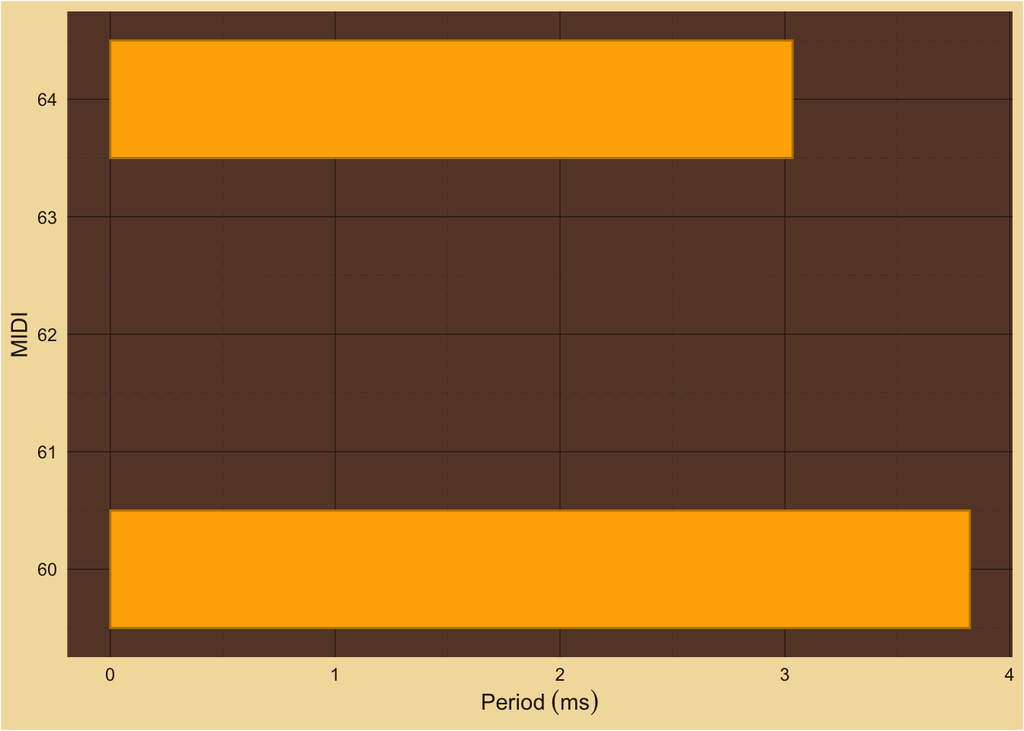

##### Chord Period

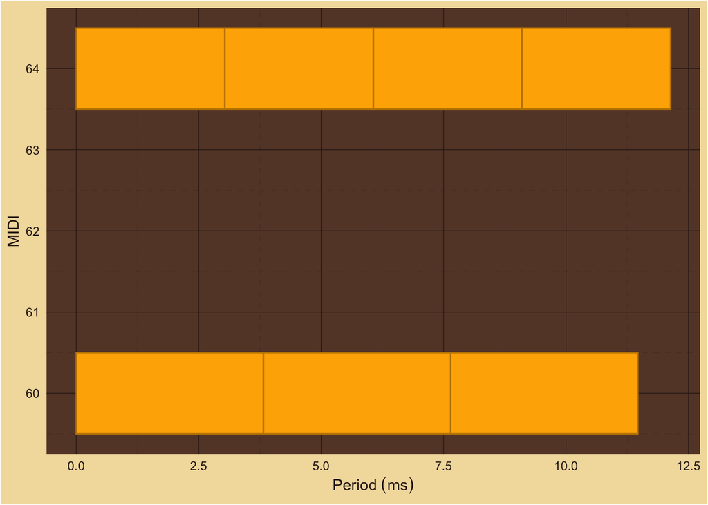

##### Frequency fractions

| index | num | den | tone_hz | freq | midi | pseudo_rational_number |
| --- | --- | --- | --- | --- | --- | --- |
| 1 | 1 | 1 | 261.6256 | 261.6256 | 60 | 1.000000 |
| 2 | 4 | 3 | 329.6276 | 329.6276 | 64 | 1.259921 |

#### Spatial Periodicity

| lcd | chord_Sz | chord_Hz | c_sound | chord_m | chord_s |
| --- | --- | --- | --- | --- | --- |
| 3 | 1.584963 | 87.20852 | 343 | 3.933102 | 0.0114668 |

##### Partial Wavelengths

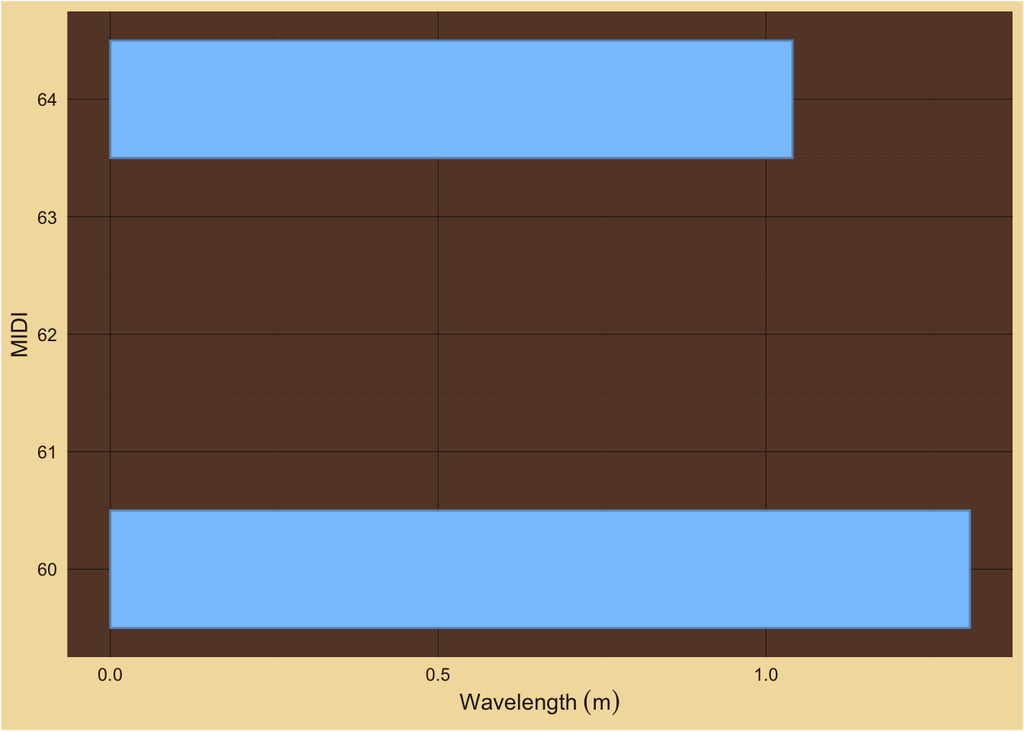

##### Chord Wavelength

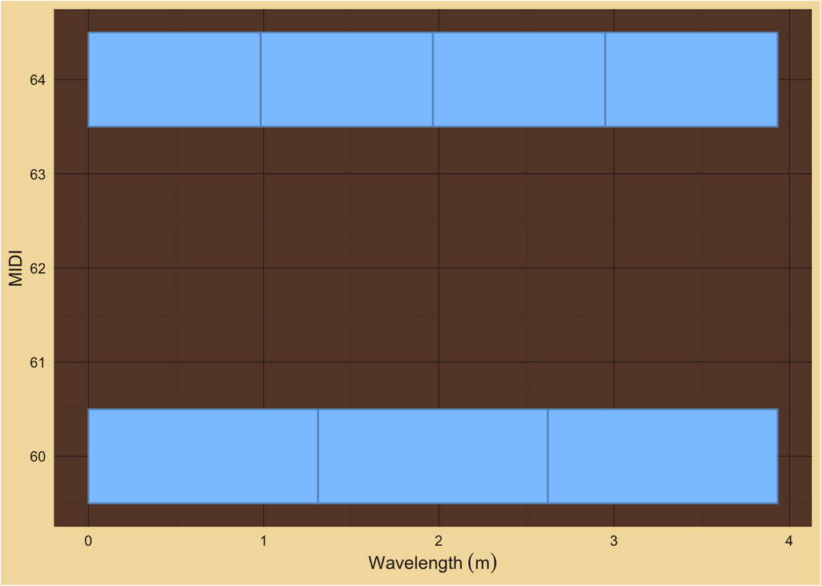

##### Wavelength fractions

| index | num | den | tone_m | freq | midi | pseudo_rational_number |
| --- | --- | --- | --- | --- | --- | --- |
| 1 | 4 | 3 | 1.311034 | 261.6256 | 60 | 1.259921 |
| 2 | 1 | 1 | 1.040568 | 329.6276 | 64 | 1.000000 |

#### 10 Harmonics

- Fundamentals in MIDI: 60, 64
- Number of Harmonics: 10
- Frequencies: 261.626, 329.628, 523.251, 659.255, 784.877, 988.883, 1046.502, 1308.128, 1318.510, 1569.753, 1648.138, 1831.379, 1977.765, 2093.005, 2307.393, 2354.630, 2616.256, 2637.020, 2966.648, 3296.276
- Wavelengths: 1.311, 1.041, 0.656, 0.520, 0.437, 0.347, 0.328, 0.262, 0.260, 0.219, 0.208, 0.187, 0.173, 0.164, 0.149, 0.146, 0.131, 0.130, 0.116, 0.104
- Speed of Sound: 343.000
- f0: 21.802
- l0: 78.662
- Quantum Speed of Sound: 1715.000

###### MaMi.CoDi Predictions

| dissonance | major | log2_temporal_cycles | log2_spatial_cycles |
| --- | --- | --- | --- |
| 90.50815 | 2.321928 | 46.41504 | 44.09311 |

#### Temporal Periodicity

| lcd | chord_Sz | chord_Hz | c_sound | chord_m | chord_s |
| --- | --- | --- | --- | --- | --- |
| 12 | 3.584963 | 21.80213 | 343 | 15.73241 | 0.0458671 |

##### Partial Periods

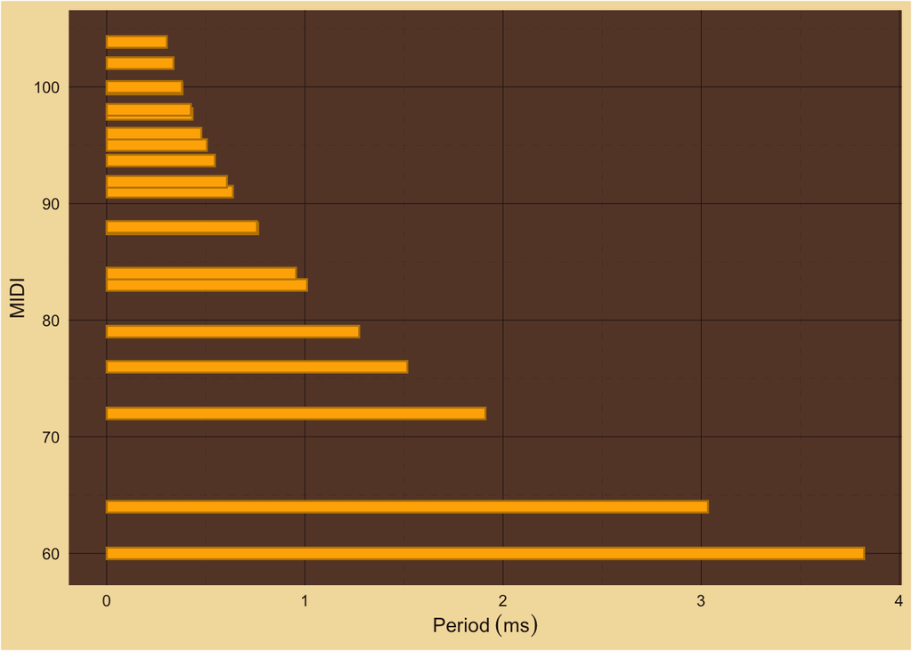

##### Chord Period

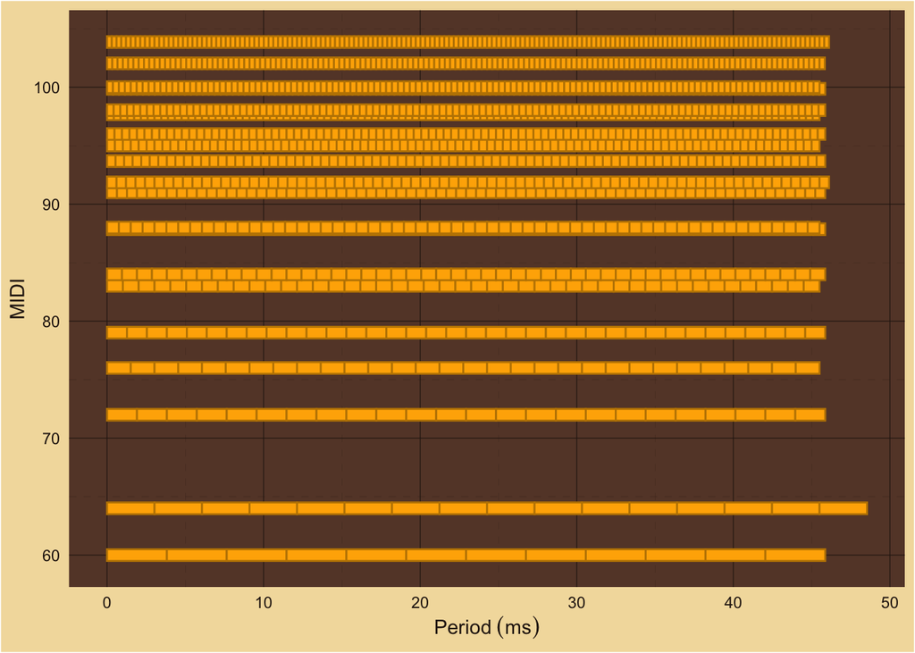

##### Frequency fractions

| index | num | den | tone_hz | freq | midi | pseudo_rational_number |
| --- | --- | --- | --- | --- | --- | --- |
| 1 | 1 | 1 | 261.6256 | 261.6256 | 60.00000 | 1.000000 |
| 2 | 4 | 3 | 329.6276 | 329.6276 | 64.00000 | 1.259921 |
| 3 | 2 | 1 | 523.2511 | 523.2511 | 72.00000 | 2.000000 |
| 4 | 5 | 2 | 659.2551 | 659.2551 | 76.00000 | 2.519842 |
| 5 | 3 | 1 | 784.8767 | 784.8767 | 79.01955 | 3.000000 |
| 6 | 15 | 4 | 988.8827 | 988.8827 | 83.01955 | 3.779763 |
| 7 | 4 | 1 | 1046.5023 | 1046.5023 | 84.00000 | 4.000000 |
| 8 | 5 | 1 | 1308.1278 | 1308.1278 | 87.86314 | 5.000000 |
| 9 | 5 | 1 | 1318.5102 | 1318.5102 | 88.00000 | 5.039684 |
| 10 | 6 | 1 | 1569.7534 | 1569.7534 | 91.01955 | 6.000000 |
| 11 | 19 | 3 | 1648.1378 | 1648.1378 | 91.86314 | 6.299605 |
| 12 | 7 | 1 | 1831.3790 | 1831.3790 | 93.68826 | 7.000000 |
| 13 | 15 | 2 | 1977.7653 | 1977.7653 | 95.01955 | 7.559526 |
| 14 | 8 | 1 | 2093.0045 | 2093.0045 | 96.00000 | 8.000000 |
| 15 | 35 | 4 | 2307.3929 | 2307.3929 | 97.68826 | 8.819447 |
| 16 | 9 | 1 | 2354.6301 | 2354.6301 | 98.03910 | 9.000000 |
| 17 | 10 | 1 | 2616.2556 | 2616.2556 | 99.86314 | 10.000000 |
| 18 | 10 | 1 | 2637.0205 | 2637.0205 | 100.00000 | 10.079368 |
| 19 | 34 | 3 | 2966.6480 | 2966.6480 | 102.03910 | 11.339289 |
| 20 | 38 | 3 | 3296.2755 | 3296.2755 | 103.86314 | 12.599210 |

#### Spatial Periodicity

| lcd | chord_Sz | chord_Hz | c_sound | chord_m | chord_s |
| --- | --- | --- | --- | --- | --- |
| 60 | 5.906891 | 4.360426 | 343 | 78.66204 | 0.2293354 |

##### Partial Wavelengths

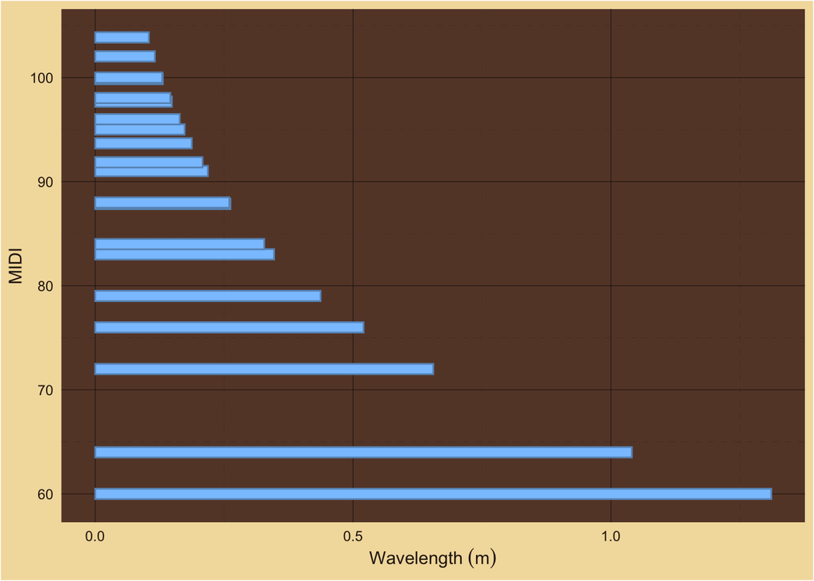

##### Chord Wavelength

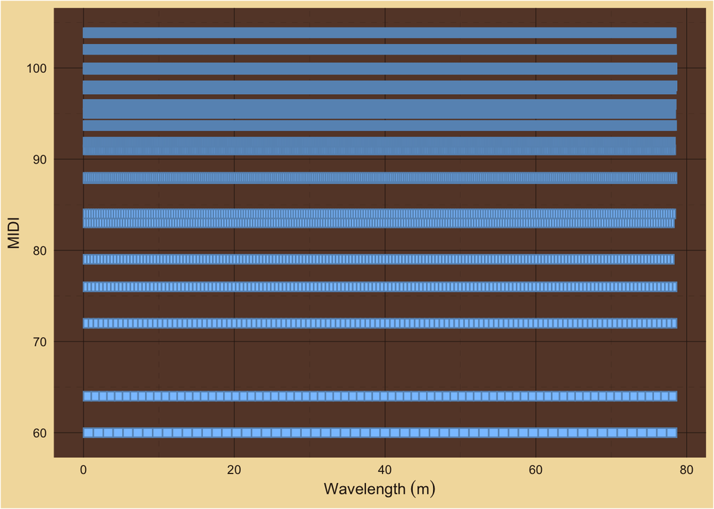

##### Wavelength fractions

| index | num | den | tone_m | freq | midi | pseudo_rational_number |
| --- | --- | --- | --- | --- | --- | --- |
| 1 | 38 | 3 | 1.3110340 | 261.6256 | 60.00000 | 12.599210 |
| 2 | 10 | 1 | 1.0405683 | 329.6276 | 64.00000 | 10.000000 |
| 3 | 19 | 3 | 0.6555170 | 523.2511 | 72.00000 | 6.299605 |
| 4 | 5 | 1 | 0.5202842 | 659.2551 | 76.00000 | 5.000000 |
| 5 | 17 | 4 | 0.4370113 | 784.8767 | 79.01955 | 4.199737 |
| 6 | 10 | 3 | 0.3468561 | 988.8827 | 83.01955 | 3.333333 |
| 7 | 16 | 5 | 0.3277585 | 1046.5023 | 84.00000 | 3.149803 |
| 8 | 5 | 2 | 0.2622068 | 1308.1278 | 87.86314 | 2.519842 |
| 9 | 5 | 2 | 0.2601421 | 1318.5102 | 88.00000 | 2.500000 |
| 10 | 13 | 6 | 0.2185057 | 1569.7534 | 91.01955 | 2.099868 |
| 11 | 2 | 1 | 0.2081137 | 1648.1378 | 91.86314 | 2.000000 |
| 12 | 7 | 4 | 0.1872906 | 1831.3790 | 93.68826 | 1.799887 |
| 13 | 5 | 3 | 0.1734281 | 1977.7653 | 95.01955 | 1.666667 |
| 14 | 3 | 2 | 0.1638792 | 2093.0045 | 96.00000 | 1.574901 |
| 15 | 3 | 2 | 0.1486526 | 2307.3929 | 97.68826 | 1.428571 |
| 16 | 4 | 3 | 0.1456704 | 2354.6301 | 98.03910 | 1.399912 |
| 17 | 4 | 3 | 0.1311034 | 2616.2556 | 99.86314 | 1.259921 |
| 18 | 5 | 4 | 0.1300710 | 2637.0205 | 100.00000 | 1.250000 |
| 19 | 7 | 6 | 0.1156187 | 2966.6480 | 102.03910 | 1.111111 |
| 20 | 1 | 1 | 0.1040568 | 3296.2755 | 103.86314 | 1.000000 |

#### 20 Harmonics

- Fundamentals in MIDI: 60, 64
- Number of Harmonics: 20
- Frequencies: 261.626, 329.628, 523.251, 659.255, 784.877, 988.883, 1046.502, 1308.128, 1318.510, 1569.753, 1648.138, 1831.379, 1977.765, 2093.005, 2307.393, 2354.630, 2616.256, 2637.020, 2877.881, 2966.648, 3139.507, 3296.276, 3401.132, 3625.903, 3662.758, 3924.383, 3955.531, 4186.009, 4285.158, 4447.635, 4614.786, 4709.260, 4944.413, 4970.886, 5232.511, 5274.041, 5603.668, 5933.296, 6262.924, 6592.551
- Wavelengths: 1.311, 1.041, 0.656, 0.520, 0.437, 0.347, 0.328, 0.262, 0.260, 0.219, 0.208, 0.187, 0.173, 0.164, 0.149, 0.146, 0.131, 0.130, 0.119, 0.116, 0.109, 0.104, 0.101, 0.095, 0.094, 0.087, 0.087, 0.082, 0.080, 0.077, 0.074, 0.073, 0.069, 0.069, 0.066, 0.065, 0.061, 0.058, 0.055, 0.052
- Speed of Sound: 343.000
- f0: 4.360
- l0: 78.662
- Quantum Speed of Sound: 343.000

###### MaMi.CoDi Predictions

| dissonance | major | log2_temporal_cycles | log2_spatial_cycles |
| --- | --- | --- | --- |
| 88.18622 | 0 | 44.09311 | 44.09311 |

#### Temporal Periodicity

| lcd | chord_Sz | chord_Hz | c_sound | chord_m | chord_s |
| --- | --- | --- | --- | --- | --- |
| 60 | 5.906891 | 4.360426 | 343 | 78.66204 | 0.2293354 |

##### Partial Periods

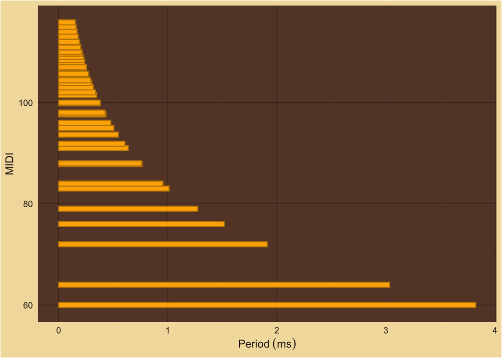

##### Chord Period

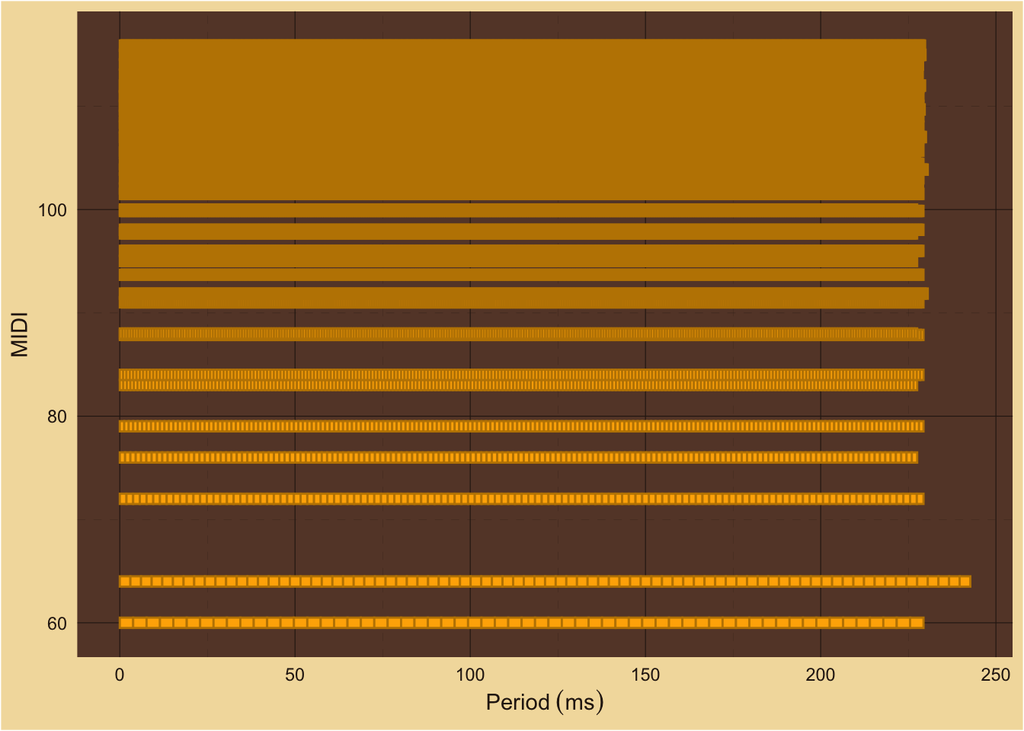

##### Frequency fractions

| index | num | den | tone_hz | freq | midi | pseudo_rational_number |
| --- | --- | --- | --- | --- | --- | --- |
| 1 | 1 | 1 | 261.6256 | 261.6256 | 60.00000 | 1.000000 |
| 2 | 4 | 3 | 329.6276 | 329.6276 | 64.00000 | 1.259921 |
| 3 | 2 | 1 | 523.2511 | 523.2511 | 72.00000 | 2.000000 |
| 4 | 5 | 2 | 659.2551 | 659.2551 | 76.00000 | 2.519842 |
| 5 | 3 | 1 | 784.8767 | 784.8767 | 79.01955 | 3.000000 |
| 6 | 15 | 4 | 988.8827 | 988.8827 | 83.01955 | 3.779763 |
| 7 | 4 | 1 | 1046.5023 | 1046.5023 | 84.00000 | 4.000000 |
| 8 | 5 | 1 | 1308.1278 | 1308.1278 | 87.86314 | 5.000000 |
| 9 | 5 | 1 | 1318.5102 | 1318.5102 | 88.00000 | 5.039684 |
| 10 | 6 | 1 | 1569.7534 | 1569.7534 | 91.01955 | 6.000000 |
| 11 | 19 | 3 | 1648.1378 | 1648.1378 | 91.86314 | 6.299605 |
| 12 | 7 | 1 | 1831.3790 | 1831.3790 | 93.68826 | 7.000000 |
| 13 | 15 | 2 | 1977.7653 | 1977.7653 | 95.01955 | 7.559526 |
| 14 | 8 | 1 | 2093.0045 | 2093.0045 | 96.00000 | 8.000000 |
| 15 | 35 | 4 | 2307.3929 | 2307.3929 | 97.68826 | 8.819447 |
| 16 | 9 | 1 | 2354.6301 | 2354.6301 | 98.03910 | 9.000000 |
| 17 | 10 | 1 | 2616.2556 | 2616.2556 | 99.86314 | 10.000000 |
| 18 | 10 | 1 | 2637.0205 | 2637.0205 | 100.00000 | 10.079368 |
| 19 | 11 | 1 | 2877.8811 | 2877.8811 | 101.51318 | 11.000000 |
| 20 | 34 | 3 | 2966.6480 | 2966.6480 | 102.03910 | 11.339289 |
| 21 | 12 | 1 | 3139.5068 | 3139.5068 | 103.01955 | 12.000000 |
| 22 | 38 | 3 | 3296.2755 | 3296.2755 | 103.86314 | 12.599210 |
| 23 | 13 | 1 | 3401.1324 | 3401.1324 | 104.40528 | 13.000000 |
| 24 | 69 | 5 | 3625.9030 | 3625.9030 | 105.51318 | 13.859131 |
| 25 | 14 | 1 | 3662.7579 | 3662.7579 | 105.68826 | 14.000000 |
| 26 | 15 | 1 | 3924.3834 | 3924.3834 | 106.88269 | 15.000000 |
| 27 | 91 | 6 | 3955.5307 | 3955.5307 | 107.01955 | 15.119053 |
| 28 | 16 | 1 | 4186.0090 | 4186.0090 | 108.00000 | 16.000000 |
| 29 | 49 | 3 | 4285.1583 | 4285.1583 | 108.40528 | 16.378974 |
| 30 | 17 | 1 | 4447.6346 | 4447.6346 | 109.04955 | 17.000000 |
| 31 | 53 | 3 | 4614.7858 | 4614.7858 | 109.68826 | 17.638895 |
| 32 | 18 | 1 | 4709.2602 | 4709.2602 | 110.03910 | 18.000000 |
| 33 | 113 | 6 | 4944.4133 | 4944.4133 | 110.88269 | 18.898816 |
| 34 | 19 | 1 | 4970.8857 | 4970.8857 | 110.97513 | 19.000000 |
| 35 | 20 | 1 | 5232.5113 | 5232.5113 | 111.86314 | 20.000000 |
| 36 | 101 | 5 | 5274.0409 | 5274.0409 | 112.00000 | 20.158737 |
| 37 | 107 | 5 | 5603.6684 | 5603.6684 | 113.04955 | 21.418658 |
| 38 | 68 | 3 | 5933.2960 | 5933.2960 | 114.03910 | 22.678579 |
| 39 | 24 | 1 | 6262.9235 | 6262.9235 | 114.97513 | 23.938500 |
| 40 | 101 | 4 | 6592.5511 | 6592.5511 | 115.86314 | 25.198421 |

#### Spatial Periodicity

| lcd | chord_Sz | chord_Hz | c_sound | chord_m | chord_s |
| --- | --- | --- | --- | --- | --- |
| 60 | 5.906891 | 4.360426 | 343 | 78.66204 | 0.2293354 |

##### Partial Wavelengths

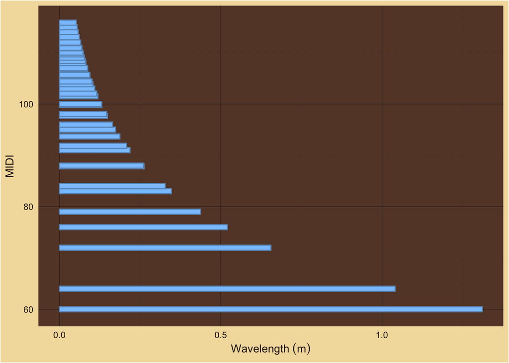

##### Chord Wavelength

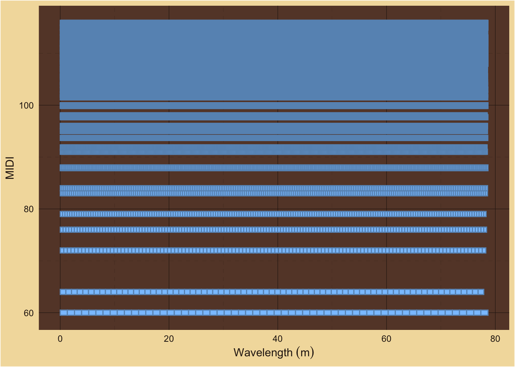

##### Wavelength fractions

| index | num | den | tone_m | freq | midi | pseudo_rational_number |
| --- | --- | --- | --- | --- | --- | --- |
| 1 | 101 | 4 | 1.3110340 | 261.6256 | 60.00000 | 25.198421 |
| 2 | 20 | 1 | 1.0405683 | 329.6276 | 64.00000 | 20.000000 |
| 3 | 38 | 3 | 0.6555170 | 523.2511 | 72.00000 | 12.599210 |
| 4 | 10 | 1 | 0.5202842 | 659.2551 | 76.00000 | 10.000000 |
| 5 | 25 | 3 | 0.4370113 | 784.8767 | 79.01955 | 8.399474 |
| 6 | 20 | 3 | 0.3468561 | 988.8827 | 83.01955 | 6.666667 |
| 7 | 19 | 3 | 0.3277585 | 1046.5023 | 84.00000 | 6.299605 |
| 8 | 5 | 1 | 0.2622068 | 1308.1278 | 87.86314 | 5.039684 |
| 9 | 5 | 1 | 0.2601421 | 1318.5102 | 88.00000 | 5.000000 |
| 10 | 17 | 4 | 0.2185057 | 1569.7534 | 91.01955 | 4.199737 |
| 11 | 4 | 1 | 0.2081137 | 1648.1378 | 91.86314 | 4.000000 |
| 12 | 11 | 3 | 0.1872906 | 1831.3790 | 93.68826 | 3.599774 |
| 13 | 10 | 3 | 0.1734281 | 1977.7653 | 95.01955 | 3.333333 |
| 14 | 16 | 5 | 0.1638792 | 2093.0045 | 96.00000 | 3.149803 |
| 15 | 14 | 5 | 0.1486526 | 2307.3929 | 97.68826 | 2.857143 |
| 16 | 11 | 4 | 0.1456704 | 2354.6301 | 98.03910 | 2.799825 |
| 17 | 5 | 2 | 0.1311034 | 2616.2556 | 99.86314 | 2.519842 |
| 18 | 5 | 2 | 0.1300710 | 2637.0205 | 100.00000 | 2.500000 |
| 19 | 7 | 3 | 0.1191849 | 2877.8811 | 101.51318 | 2.290766 |
| 20 | 9 | 4 | 0.1156187 | 2966.6480 | 102.03910 | 2.222222 |
| 21 | 13 | 6 | 0.1092528 | 3139.5068 | 103.01955 | 2.099868 |
| 22 | 2 | 1 | 0.1040568 | 3296.2755 | 103.86314 | 2.000000 |
| 23 | 2 | 1 | 0.1008488 | 3401.1324 | 104.40528 | 1.938340 |
| 24 | 7 | 4 | 0.0945971 | 3625.9030 | 105.51318 | 1.818182 |
| 25 | 7 | 4 | 0.0936453 | 3662.7579 | 105.68826 | 1.799887 |
| 26 | 5 | 3 | 0.0874023 | 3924.3834 | 106.88269 | 1.679895 |
| 27 | 5 | 3 | 0.0867140 | 3955.5307 | 107.01955 | 1.666667 |
| 28 | 3 | 2 | 0.0819396 | 4186.0090 | 108.00000 | 1.574901 |
| 29 | 3 | 2 | 0.0800437 | 4285.1583 | 108.40528 | 1.538461 |
| 30 | 3 | 2 | 0.0771196 | 4447.6346 | 109.04955 | 1.482260 |
| 31 | 3 | 2 | 0.0743263 | 4614.7858 | 109.68826 | 1.428571 |
| 32 | 4 | 3 | 0.0728352 | 4709.2602 | 110.03910 | 1.399912 |
| 33 | 4 | 3 | 0.0693712 | 4944.4133 | 110.88269 | 1.333333 |
| 34 | 4 | 3 | 0.0690018 | 4970.8857 | 110.97513 | 1.326233 |
| 35 | 4 | 3 | 0.0655517 | 5232.5113 | 111.86314 | 1.259921 |
| 36 | 5 | 4 | 0.0650355 | 5274.0409 | 112.00000 | 1.250000 |
| 37 | 5 | 4 | 0.0612099 | 5603.6684 | 113.04955 | 1.176471 |
| 38 | 7 | 6 | 0.0578094 | 5933.2960 | 114.03910 | 1.111111 |
| 39 | 1 | 1 | 0.0547668 | 6262.9235 | 114.97513 | 1.052632 |
| 40 | 1 | 1 | 0.0520284 | 6592.5511 | 115.86314 | 1.000000 |